# Time Series and PP Team Supplemental Data

2022-06-08

The following provides documentation of the process and results of the time series and supplemental data provided to the Public Policy Team for their final report and presentation. The 2016-2020 ACS 5-year datasets can be found at [link](https://api.census.gov/data/2020/acs/acs5/variables.html)

## Contents

- Setup and Datasets Used
- Housing Inventory Data
- Rent Burden Data
- Median Income Data
- Population and Demographic Information
- Time Series
  - Corporate Ownership Analysis
  - Large Landlords in Bay Area
  - Total # Of Sold Properties
  - Foreclosed Properties
  - Transaction Times
  - Median Sale Prices by Tenure
  - Unused and Unproductive Code
- Leaflet Setup

## Setup and Datasets Used

```r
library(dplyr)
library(tidyverse)
library(ggplot2)
library(stringr)
library(censusapi)
library(tigris)
library(leaflet)
```

```r
opaeligibility <- readRDS("G:/Shared drives/S22 218Z/Housing (OPA)/opaeligibility.rds")
deed_condensed <- readRDS("G:/Shared drives/S22 218Z/Housing (OPA)/deed_condensed.rds")
epa_combined <- readRDS("G:/Shared drives/S22 218Z/Housing (OPA)/epa_combined.rds")
tax_epa_apn <- readRDS("G:/Shared drives/S22 218Z/Housing (OPA)/tax_epa_apn.rds")
tax_bay <- readRDS("G:/Shared drives/S22 218Z/Housing (OPA)/tax_bay.rds")
qh_epa <- readRDS("G:/Shared drives/S22 218Z/Housing (OPA)/MLS Data/qh_epa.rds")
```

## Housing Inventory Data

I used 2016-2020 ACS 5-year data to compile several housing inventory variables for East Palo Alto.

- B25001: HOUSING UNITS
- B25002: OCCUPANCY STATUS
- B25003: TENURE
- B25008: TOTAL POPULATION IN OCCUPIED HOUSING UNITS BY TENURE
- B25024: UNITS IN STRUCTURE

```r
unit_table <- getCensus(
  name = "acs/acs5",
  vintage = 2020,
  region = "block group:*",
  regionin = "state:06+county:081",
  vars = "group(B25001)"
  ) %>%
  filter(tract %in% c("611800", "611900", "611901", "611902", "612000", "612001", "612002", "612100", "612101", "612102")) %>%
  mutate(
    cbg =
      paste0(state,county,tract,block_group)
  ) %>%
  select(!c(GEO_ID,state,county,tract,block_group,NAME) & !ends_with(c("EA","MA","M"))) %>%
  pivot_longer(
    ends_with("E"),
    names_to = "variable",
    values_to = "Total Housing Units (25001)"
  ) %>%
  select(!variable)

unit_table <- getCensus(
  name = "acs/acs5",
  vintage = 2020,
  region = "block group:*",
  regionin = "state:06+county:081",
  vars = "group(B25002)"
  ) %>%
  filter(tract %in% c("611800", "611900", "611901", "611902", "612000", "612001", "612002", "612100", "612101", "612102")) %>%
  mutate(
    cbg =
      paste0(state,county,tract,block_group)
  ) %>%
  select(!c(GEO_ID,state,county,tract,block_group,NAME) & !ends_with(c("EA","MA","M"))) %>%
  rename("Total Occupied Units (25002)" = "B25002_002E") %>% rename("Total Vacant Units (25002)" = "B25002_003E") %>% select(!B25002_001E) %>% left_join(unit_table, by = "cbg")

unit_table <- getCensus(
  name = "acs/acs5",
  vintage = 2020,
  region = "block group:*",
  regionin = "state:06+county:081",
  vars = "group(B25003)"
  ) %>%
  filter(tract %in% c("611800", "611900", "611901", "611902", "612000", "612001", "612002", "612100", "612101", "612102")) %>%
  mutate(
    cbg =
      paste0(state,county,tract,block_group)
  ) %>%
  select(!c(GEO_ID,state,county,tract,block_group,NAME) & !ends_with(c("EA","MA","M"))) %>%
  rename("Owner Occupied Units (25003)" = "B25003_002E") %>% rename("Renter Occupied Units (25003)" = "B25003_003E") %>% select(!B25003_001E) %>% left_join(unit_table, by = "cbg")

unit_table <- getCensus(
  name = "acs/acs5",
  vintage = 2020,
  region = "block group:*",
  regionin = "state:06+county:081",
  vars = "group(B25008)"
  ) %>%
  filter(tract %in% c("611800", "611900", "611901", "611902", "612000", "612001", "612002", "612100", "612101", "612102")) %>%
  mutate(
    cbg =
      paste0(state,county,tract,block_group)
  ) %>%
  select(!c(GEO_ID,state,county,tract,block_group,NAME) & !ends_with(c("EA","MA","M"))) %>%
  rename("EPA Population in Owner Occupied (25008)" = "B25008_002E") %>% rename("EPA Population in Renter Occupied (25008)" = "B25008_003E") %>% select(!B25008_001E) %>% left_join(unit_table, by = "cbg")

unit_table <- getCensus(
  name = "acs/acs5",
  vintage = 2020,
  region = "block group:*",
  regionin = "state:06+county:081",
  vars = "group(B25024)"
  ) %>%
  filter(tract %in% c("611800", "611900", "611901", "611902", "612000", "612001", "612002", "612100", "612101", "612102")) %>%
  mutate(
    cbg =
      paste0(state,county,tract,block_group)
  ) %>%
  select(!c(GEO_ID,state,county,tract,block_group,NAME) & !ends_with(c("EA","MA","M"))) %>%
  rename(c("1, detached" = "B25024_002E", "1, attached" = "B25024_003E", "2" = "B25024_004E", "3 or 4" = "B25024_005E", "5 to 9" = "B25024_006E", "10 to 19" = "B25024_007E", "20 to 49" = "B25024_008E", "50 or more" = "B25024_009E", "Mobile home" = "B25024_010E", "Boat, RV, Van, etc." = "B25024_011E" )) %>% select(!B25024_001E) %>% left_join(unit_table, by = "cbg")
```

The code below simply rearranges column orders for better legibility.

```r
unit_table <- unit_table[, c(11, 12, 13, 14, 15, 16, 17, 18, 1, 2, 3, 4, 5, 6, 7, 8, 9, 10)]
```

## Rent Burden Analysis

I used 2016-2020 ACS 5-year data to compile rental burden statistics for East Palo Alto, San Mateo County, and the Bay Area:

- B25074: HOUSEHOLD INCOME BY GROSS RENT AS A PERCENTAGE OF HOUSEHOLD INCOME IN THE PAST 12 MONTHS
- B25070: GROSS RENT AS A PERCENTAGE OF HOUSEHOLD INCOME IN THE PAST 12 MONTHS

Here, the Bay Area is defined as 9 counties: Alameda (001), Contra Costa (013), Marin (041), Napa (055), San Francisco (075), San Mateo (081), Santa Clara (085), Solano (095), and Sonoma (097).

```r
HH_rent_EPA <- getCensus(
  name = "acs/acs5",
  vintage = 2020,
  region = "block group:*",
  regionin = "state:06+county:081",
  vars = "group(B25074)"
  ) %>%
  filter(tract %in% c("611800", "611900", "611901", "611902", "612000", "612001", "612002", "612100", "612101", "612102")) %>%
  mutate(
    cbg =
      paste0(state,county,tract,block_group)
  ) %>%
  select(!c(GEO_ID,state,county,tract,block_group, NAME) & !ends_with(c("EA","MA","M")))
```

```r
HH_rent_SMC <- getCensus(
  name = "acs/acs5",
  vintage = 2020,
  region = "block group:*",
  regionin = "state:06+county:081",
  vars = "group(B25074)"
  ) %>%
  mutate(
    cbg =
      paste0(state,county,tract,block_group)
  ) %>%
  select(!c(GEO_ID,state,county,tract,block_group, NAME) & !ends_with(c("EA","MA","M")))
```

```r
HH_rent_bay <- getCensus(
  name = "acs/acs5",
  vintage = 2020,
  region = "block group:*",
  regionin = "state:06+county:001,013,041,055,075,081,085,095,097",
  vars = "group(B25074)"
  ) %>%
  mutate(
    cbg =
      paste0(state,county,tract,block_group)
  ) %>%
  select(!c(GEO_ID,state,county,tract,block_group, NAME) & !ends_with(c("EA","MA","M")))
```

The following code was used to rename columns for better legibility.

```r
#colnames(HH_rent_bay) <- c("Total", "Less than $10,000", "Less than $10,000, Less than 20.0 percent", "Less than $10,000, 20.0 to 24.9 percent", "Less than $10,000, 25.0 to 29.9 percent", "Less than $10,000, 30.0 to 34.9 percent", "Less than $10,000, 35.0 to 39.9 percent", "Less than $10,000, 40.0 to 49.9 percent", "Less than $10,000, 50 percent or more", "Less than $10,000, Not Computed", "$10,000 to $19,999", "$10,000 to $19,999, Less than 20.0 percent", "$10,000 to $19,999, 20.0 to 24.9 percent", "$10,000 to $19,999, 25.0 to 29.9 percent", "$10,000 to $19,999, 30.0 to 34.9 percent", "$10,000 to $19,999, 35.0 to 39.9 percent", "$10,000 to $19,999, 40.0 to 49.9 percent", "$10,000 to $19,999, 50 percent or more", "$10,000 to $19,999, Not Computed", "$20,000 to $34,999", "$20,000 to $34,999, Less than 20.0 percent", "$20,000 to $34,999, 20.0 to 24.9 percent", "$20,000 to $34,999, 25.0 to 29.9 percent", "$20,000 to $34,999, 30.0 to 34.9 percent", "$20,000 to $34,999, 35.0 to 39.9 percent", "$20,000 to $34,999, 40.0 to 49.9 percent", "$20,000 to $34,999, 50 percent or more", "$20,000 to $34,999, Not Computed", "$35,000 to $49,999", "$35,000 to $49,999, Less than 20.0 percent", "$35,000 to $49,999, 20.0 to 24.9 percent", "$35,000 to $49,999, 25.0 to 29.9 percent", "$35,000 to $49,999, 30.0 to 34.9 percent", "$35,000 to $49,999, 35.0 to 39.9 percent", "$35,000 to $49,999, 40.0 to 49.9 percent", "$35,000 to $49,999, 50 percent or more", "$35,000 to $49,999, Not Computed", "$50,000 to $74,999", "$50,000 to $74,999, Less than 20.0 percent", "$50,000 to $74,999, 20.0 to 24.9 percent", "$50,000 to $74,999, 25.0 to 29.9 percent", "$50,000 to $74,999, 30.0 to 34.9 percent", "$50,000 to $74,999, 35.0 to 39.9 percent", "$50,000 to $74,999, 40.0 to 49.9 percent", "$50,000 to $74,999, 50 percent or more", "$50,000 to $74,999, Not Computed", "$75,000 to $99,999", "$75,000 to $99,999, Less than 20.0 percent", "$75,000 to $99,999, 20.0 to 24.9 percent", "$75,000 to $99,999, 25.0 to 29.9 percent", "$75,000 to $99,999, 30.0 to 34.9 percent", "$75,000 to $99,999, 35.0 to 39.9 percent", "$75,000 to $99,999, 40.0 to 49.9 percent", "$75,000 to $99,999, 50 percent or more", "$75,000 to $99,999, Not Computed", "$100,000 or more", "$100,000 or more, Less than 20.0 percent", "$100,000 or more, 20.0 to 24.9 percent", "$100,000 or more, 25.0 to 29.9 percent", "$100,000 or more, 30.0 to 34.9 percent", "$$100,000 or more, 35.0 to 39.9 percent", "$100,000 or more, 40.0 to 49.9 percent", "$100,000 or more, 50 percent or more", "$100,000 or more, Not Computed")
```

```r
rent_burden <- getCensus(
  name = "acs/acs5",
  vintage = 2020,
  region = "block group:*",
  regionin = "state:06+county:081",
  vars = "group(B25070)"
  ) %>%
  filter(tract %in% c("611800", "611900", "611901", "611902", "612000", "612001", "612002", "612100", "612101", "612102")) %>%
  mutate(
    cbg =
      paste0(state,county,tract,block_group)
  ) %>%
  select(!c(GEO_ID,state,county,tract,block_group,NAME) & !ends_with(c("EA","MA","M"))) %>%
  rename(c("Less than 10%" = "B25070_002E", "10 to 14.9%" = "B25070_003E", "15 to 19.9%" = "B25070_004E", "20 to 24.9%" = "B25070_005E", "25 to 29.9%" = "B25070_006E", "30 to 34.9%" = "B25070_007E", "35 to 39.9%" = "B25070_008E", "40 to 49.9%" = "B25070_009E", "50% or More" = "B25070_010E", "Not computed" = "B25070_011E" ))
```

```r
rent_burden_smc <- getCensus(
  name = "acs/acs5",
  vintage = 2020,
  region = "block group:*",
  regionin = "state:06+county:081",
  vars = "group(B25070)"
  ) %>%
  mutate(
    cbg =
      paste0(state,county,tract,block_group)
  ) %>%
  select(!c(GEO_ID,state,county,tract,block_group,NAME) & !ends_with(c("EA","MA","M"))) %>%
  rename(c("Less than 10%" = "B25070_002E", "10 to 14.9%" = "B25070_003E", "15 to 19.9%" = "B25070_004E", "20 to 24.9%" = "B25070_005E", "25 to 29.9%" = "B25070_006E", "30 to 34.9%" = "B25070_007E", "35 to 39.9%" = "B25070_008E", "40 to 49.9%" = "B25070_009E", "50% or More" = "B25070_010E", "Not computed" = "B25070_011E" ))
```

```r
rent_burden_bay <- getCensus(
  name = "acs/acs5",
  vintage = 2020,
  region = "block group:*",
  regionin = "state:06+county:001,013,041,055,075,081,085,095,097",
  vars = "group(B25070)"
  ) %>%
  mutate(
    cbg =
      paste0(state,county,tract,block_group)
  ) %>%
  select(!c(GEO_ID,state,county,tract,block_group,NAME) & !ends_with(c("EA","MA","M"))) %>%
  rename(c("Less than 10%" = "B25070_002E", "10 to 14.9%" = "B25070_003E", "15 to 19.9%" = "B25070_004E", "20 to 24.9%" = "B25070_005E", "25 to 29.9%" = "B25070_006E", "30 to 34.9%" = "B25070_007E", "35 to 39.9%" = "B25070_008E", "40 to 49.9%" = "B25070_009E", "50% or More" = "B25070_010E", "Not computed" = "B25070_011E" ))
```

## Median Income Data

I used 2016-2020 ACS 5-year data *(B19013: MEDIAN HOUSEHOLD INCOME IN THE PAST 12 MONTHS (IN 2020 INFLATION-ADJUSTED DOLLARS)* to find the median household income for San Mateo County (and can be revised for East Palo Alto and the Bay Area). This can be further manipulated to create buckets defining the degrees of socioeconomic status.

```r
median_income <- getCensus(
  name = "acs/acs5",
  vintage = 2020,
  region = "county:*",
  regionin = "state:06",
  vars = "group(B19013)"
  ) %>%
  filter(county == "081") %>%
  select(!c(GEO_ID,state,county) & !ends_with(c("EA","MA","M")))
```

## Population and Demographic Information

I used 2016-2020 ACS 5-year data *(B01003: TOTAL POPULATION)* to compile population information for East Palo Alto:

```r
pop_epa <- getCensus(
  name = "acs/acs5",
  vintage = 2020,
  region = "block group:*",
  regionin = "state:06+county:081",
  vars = "group(B01003)"
  ) %>%
  filter(tract %in% c("611800", "611900", "611901", "611902", "612000", "612001", "612002", "612100", "612101", "612102")) %>%
  mutate(
    cbg =
      paste0(state,county,tract,block_group)
  ) %>%
  select(!c(GEO_ID,state,county,tract,block_group,NAME) & !ends_with(c("EA","MA","M"))) %>%
  rename("Population" = "B01003_001E")
```

```r
demo_epa <- getCensus(
  name = "acs/acs5",
  vintage = 2020,
  region = "block group:*",
  regionin = "state:06+county:081",
  vars = "group(B02001)"
  ) %>%
  filter(tract %in% c("611800", "611900", "611901", "611902", "612000", "612001", "612002", "612100", "612101", "612102")) %>%
  mutate(
    cbg =
      paste0(state,county,tract,block_group)
  ) %>%
  select(!c(GEO_ID,state,county,tract,block_group,NAME) & !ends_with(c("EA","MA","M"))) %>%
  rename(c("White alone" = "B02001_002E", "Black or African American alone" = "B02001_003E", "American Indian and Alaska Native alone" = "B02001_004E", "Asian alone" = "B02001_005E", "Native Hawaiian and Other Pacific Islander alone" = "B02001_006E", "Some other race alone" = "B02001_007E", "Two or more races" = "B02001_008E", "Two races including Some other race" = "B02001_009E", "Two races excluding Some other race, and three or more races" = "B02001_010E")) %>% select(!B02001_001E)
```

```r
demo_smc <- getCensus(
  name = "acs/acs5",
  vintage = 2020,
  region = "block group:*",
  regionin = "state:06+county:081",
  vars = "group(B25070)"
  ) %>%
  mutate(
    cbg =
      paste0(state,county,tract,block_group)
  ) %>%
  select(!c(GEO_ID,state,county,tract,block_group,NAME) & !ends_with(c("EA","MA","M"))) %>%
  rename(c("Less than 10%" = "B25070_002E", "10 to 14.9%" = "B25070_003E", "15 to 19.9%" = "B25070_004E", "20 to 24.9%" = "B25070_005E", "25 to 29.9%" = "B25070_006E", "30 to 34.9%" = "B25070_007E", "35 to 39.9%" = "B25070_008E", "40 to 49.9%" = "B25070_009E", "50% or More" = "B25070_010E", "Not computed" = "B25070_011E" ))
```

```r
demo_bay <- getCensus(
  name = "acs/acs5",
  vintage = 2020,
  region = "block group:*",
  regionin = "state:06+county:001,013,041,055,075,081,085,095,097",
  vars = "group(B25070)"
  ) %>%
  mutate(
    cbg =
      paste0(state,county,tract,block_group)
  ) %>%
  select(!c(GEO_ID,state,county,tract,block_group,NAME) & !ends_with(c("EA","MA","M"))) %>%
  rename(c("Less than 10%" = "B25070_002E", "10 to 14.9%" = "B25070_003E", "15 to 19.9%" = "B25070_004E", "20 to 24.9%" = "B25070_005E", "25 to 29.9%" = "B25070_006E", "30 to 34.9%" = "B25070_007E", "35 to 39.9%" = "B25070_008E", "40 to 49.9%" = "B25070_009E", "50% or More" = "B25070_010E", "Not computed" = "B25070_011E" ))
```

## Time Series

This section contains a series of data included in the “Time Series” section, including

**Corporate Ownership Analysis**

This section outputs a table defining ownership of properties in East Palo Alto by year using CoreLogic Deed Data 2019. The symbols in the outputted table are defined below:

Association (AS), Trustee - Corporation (CE), Corporate (CO), Community Property (CP), Corporate Trust (CT), Estate (ES), Executor (EX), Husband/Wife (HW), Irrevocable Trust (IT), Joint Tenancy (JT), Life Estate (LE), Limited Partnership (LP), Living Trust (LT), Partnership (PS), Personal Trust (PT), Revocable Trust (RT), Sole Owner (SO), Separate Property (SP), Survivor (SU), Tenants in Common (TC), Trustee (TE), Trust (TR), Undivided Individual (UI)

```r
table(deed_condensed$year, deed_condensed$`OWNER RELATIONSHIP RIGHTS CODE`)
```

```
##
##         AS  CE  CO  CP  CT  ES  EX  HW  IT  JT  LE  LP  LT  PS  PT  RT  SE  SO
##   1969   0   0   0   0   0   0   0   0   0   0   0   0   0   0   0   0   0   0
##   1974   0   0   0   0   0   0   0   0   0   0   0   0   0   0   0   0   0   0
##   1976   0   0   0   0   0   0   0   0   0   0   0   0   0   0   0   0   0   0
##   1977   0   0   0   0   0   0   0   0   0   0   0   0   0   0   0   0   0   0
##   1979   0   0   0   0   0   0   0   0   0   0   0   0   0   0   0   0   0   0
##   1980   0   0   0   0   0   0   0   0   0   0   0   0   0   0   0   0   0   0
##   1981   0   0   0   0   0   0   0   0   0   0   0   0   0   0   0   0   0   0
##   1982   0   0   1   0   0   0   0   0   0   0   0   0   0   0   0   0   0   0
##   1983   0   0   0   0   0   0   0   0   0   0   0   0   0   0   0   0   0   0
##   1984   0   0   0   0   0   0   0   0   0   0   0   0   0   0   0   0   0   0
##   1985   0   0   1   0   0   0   0   0   0   0   0   0   0   0   0   0   0   0
##   1986   0   0   1   0   0   0   0   0   0   0   0   0   0   0   0   0   0   0
##   1987   0   0   6   0   0   0   0   0   0   0   0   0   0   0   0   0   0   0
```

[output cut: 79 more lines]

**Large Landlords in Bay Area**

“Large landlords” in East Palo Alto is defined as an owner who owns 1 property in East Palo Alto and 1 or more properties elsewhere in East Palo Alto or the Bay Area. The following data frame returns >1500 large landlords. I set the filters between 1 and 70, noninclusive. The upper bound of 70 eliminates about 10 larger owners (such as the State of California, San Mateo County, or corporate owners).

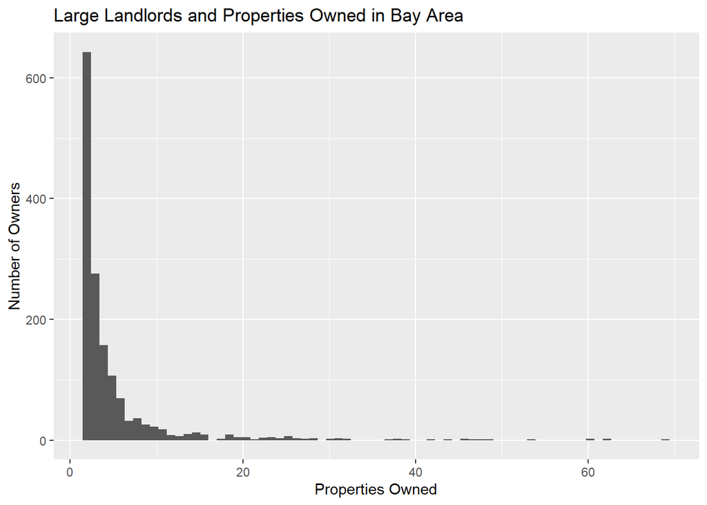

```r
tax_bay$Owner1_Name <- paste(tax_bay$`OWNER1 FIRST NAME & MI`, tax_bay$`OWNER1 LAST NAME`)

tax_epa_apn$Owner1_name <- paste(tax_epa_apn$`OWNER1 FIRST NAME & MI`, tax_epa_apn$`OWNER1 LAST NAME`)

tax_bay_filtered <- tax_bay %>% filter(Owner1_Name %in% tax_epa_apn$Owner1_name)
tax_bay_filtered$SALE_YEAR <- substr(tax_bay_filtered$`SALE DATE`, 0, 4)

landlord_hist <- data.frame(table(tax_bay_filtered$Owner1_Name)) %>% filter(Freq > 1) %>% filter(Freq < 70)
landlord_hist <- landlord_hist[order(landlord_hist$Freq, decreasing = TRUE),]
landlord_hist <- landlord_hist %>% rename(Owner_Name = Var1)
landlord_hist$Owner_Name <- gsub("NA ","",as.character(landlord_hist$Owner_Name))

ggplot(landlord_hist, aes(x = Freq)) + geom_histogram(bins = 70) + labs(x = "Properties Owned", y = "Number of Owners", title = "Large Landlords and Properties Owned in Bay Area")
```

```r
landlord_table <- data.frame(table(tax_bay_filtered$Owner1_Name, "Sale_Year" = tax_bay_filtered$SALE_YEAR)) %>% group_by(Sale_Year) %>% summarize(sum = sum(Freq))
```

**Total # Of Sold Properties**

This section outputs a table defining property sales in East Palo Alto by year using CoreLogic Deed Data 2019.

```r
data.frame(table(deed_condensed$year))
```

```
##    Var1 Freq
## 1  1969    1
## 2  1974    1
## 3  1976    2
## 4  1977    1
## 5  1979    2
## 6  1980    1
## 7  1981    2
## 8  1982    3
## 9  1983    3
## 10 1984   12
## 11 1985    7
## 12 1986   13
## 13 1987   14
## 14 1988   22
```

[output cut: 31 more lines]

**Foreclosed Properties**

```r
epa_combined$SALE_YEAR <- substr(epa_combined$`SALE DATE`, 0, 4)

sale_table <- epa_combined %>% select(SALE_YEAR,`SALE DATE`,`SALE PRICE`)

foreclosed_prop <- deed_condensed %>% filter(FORECLOSURE == "Y")
foreclosed_prop <- data.frame(table(foreclosed_prop$year))
foreclosed_prop <- foreclosed_prop %>% rename(Year = Var1)
foreclosed_prop <- foreclosed_prop %>% rename(ForeclosedProperties = Freq)

foreclosed_chart <- ggplot(foreclosed_prop, aes(x = Year, y = ForeclosedProperties)) + geom_col() + labs(x = "Year", y = "Number of Foreclosures", title = "Foreclosures in East Palo Alto, 1987-2017")
```

**Transaction Times**

This section outputs tables and graphs defining the length of sale transactions in East Palo Alto by year using CoreLogic MLS Data 2019.

Definitions:

- Transaction time: the difference between the List Date and the latest date of either Contract Date, Off Market Date, or Close Date. The following analysis accounts for All Housing Types, Single-Family Homes, 2-3 unit properties, and 4+ unit properties.
- SF: Single Family
- CN: Condo
- RI: Residential Income (2-4 units/Duplex/Triplex/Fourplex)

Transaction Times for All Housing Types in EPA:

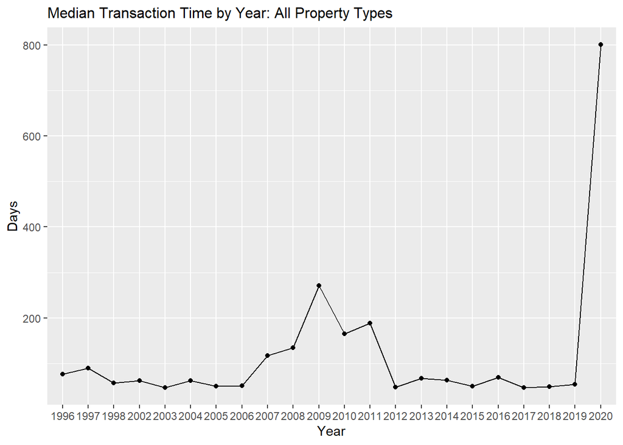

```r
qh_epa_all <- qh_epa %>%
  select(APN_new, FA_ContractDate, FA_CloseDate, FA_OffMarketDate, FA_ListDate, FA_PropertyType, NumberOfTotalUnits) %>%
  mutate_at(vars(FA_ContractDate, FA_CloseDate, FA_OffMarketDate, FA_ListDate), as.Date, format="%Y-%m-%d") %>%
  mutate(FA_PropertyType = case_when(FA_PropertyType == 'SF' ~ 'SF', FA_PropertyType %in% c('CN', 'RI') & NumberOfTotalUnits >=4 ~ '4+ Units', TRUE ~ '2-3 Units'))
qh_epa_all$max.date <- apply(qh_epa_all[,2:4],1,max, na.rm=TRUE)

qh_epa_prop2_all <- qh_epa_all %>%
  drop_na(max.date) %>%
  distinct(APN_new, max.date, .keep_all=TRUE) %>%
  mutate(transaction_time = difftime(max.date, FA_ListDate, units='days'),
         ListDateYear = format(as.Date(max.date), format="%Y"))
transaction_median_all <- qh_epa_prop2_all %>%
  group_by(ListDateYear) %>%
  summarise(median = median(transaction_time),
            n = n())

ggplot(data = transaction_median_all, aes(x = ListDateYear, y=median, group = 1)) +
  geom_line() +
  geom_point() +
  xlab("Year") +
  ylab("Days") +
  ggtitle("Median Transaction Time by Year: All Property Types") +
  theme(plot.title = element_text(size = 12))
```

Transaction Times for Single-Family Homes in EPA. This analyzes all property types labeled “SF”.

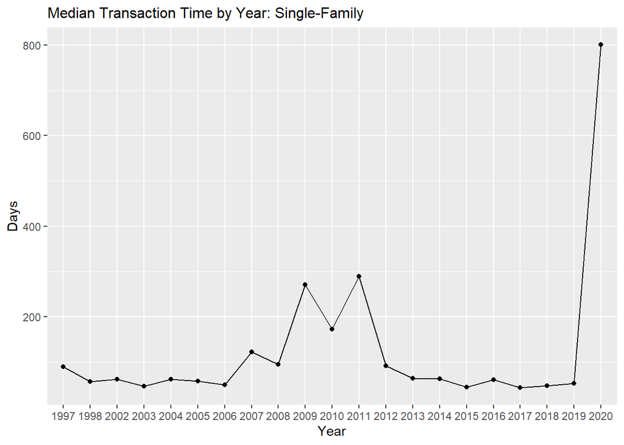

```r
qh_epa_SF <- qh_epa %>%
  filter(FA_PropertyType == "SF") %>%
  select(APN_new, FA_ContractDate, FA_CloseDate, FA_OffMarketDate, FA_ListDate, FA_PropertyType, NumberOfTotalUnits) %>%
  mutate_at(vars(FA_ContractDate, FA_CloseDate, FA_OffMarketDate, FA_ListDate), as.Date, format="%Y-%m-%d")

qh_epa_SF$max.date <- apply(qh_epa_SF[,2:4],1,max, na.rm=TRUE)

qh_epa_prop2_SF <- qh_epa_SF %>%
  drop_na(max.date) %>%
  distinct(APN_new, max.date, .keep_all=TRUE) %>%
  mutate(transaction_time = difftime(max.date, FA_ListDate, units='days'),
         ListDateYear = format(as.Date(max.date), format="%Y"))
transaction_median_SF <- qh_epa_prop2_SF %>%
  group_by(ListDateYear) %>%
  summarise(median = median(transaction_time),
            n = n())

ggplot(data = transaction_median_SF, aes(x = ListDateYear, y=median, group = 1)) +
  geom_line() +
  geom_point() +
  xlab("Year") +
  ylab("Days") +
  ggtitle("Median Transaction Time by Year: Single-Family") +
  theme(plot.title = element_text(size = 12))
```

Transaction Times for 2-3 Units in EPA. This analyzes all properties within SF, CN, and RI that are not SF or have more than 4 units:

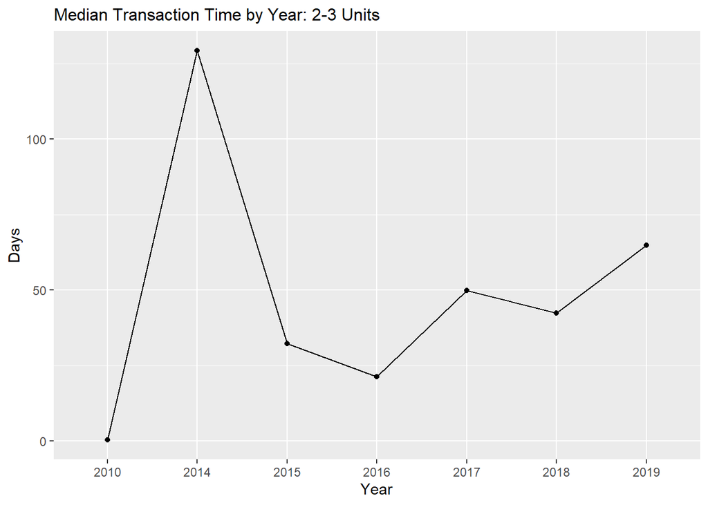

```r
qh_epa_2to3 <- qh_epa %>%
   filter(FA_PropertyType == c("SF", "CN", "RI")) %>%
  select(APN_new, FA_ContractDate, FA_CloseDate, FA_OffMarketDate, FA_ListDate, FA_PropertyType, NumberOfTotalUnits) %>%
  mutate_at(vars(FA_ContractDate, FA_CloseDate, FA_OffMarketDate, FA_ListDate), as.Date, format="%Y-%m-%d") %>% mutate(FA_PropertyType = case_when(FA_PropertyType == 'SF' ~ 'SF', FA_PropertyType %in% c('CN', 'RI') & NumberOfTotalUnits >=4 ~ '4+ Units', TRUE ~ '2-3 Units')) %>% filter(FA_PropertyType == "2-3 Units")

qh_epa_2to3$max.date <- apply(qh_epa_2to3[,2:4],1,max, na.rm=TRUE)

qh_epa_prop2_2to3 <- qh_epa_2to3 %>%
  drop_na(max.date) %>%
  distinct(APN_new, max.date, .keep_all=TRUE) %>%
  mutate(transaction_time = difftime(max.date, FA_ListDate, units='days'),
         ListDateYear = format(as.Date(max.date), format="%Y"))
transaction_median_2to3 <- qh_epa_prop2_2to3 %>%
  group_by(ListDateYear) %>%
  summarise(median = median(transaction_time),
            n = n())

ggplot(data = transaction_median_2to3, aes(x = ListDateYear, y=median, group = 1)) +
  geom_line() +
  geom_point() +
  xlab("Year") +
  ylab("Days") +
  ggtitle("Median Transaction Time by Year: 2-3 Units") +
  theme(plot.title = element_text(size = 12))
```

Transaction Times for 4+ Units in EPA. This analyzes all properties with greater than 4 units:

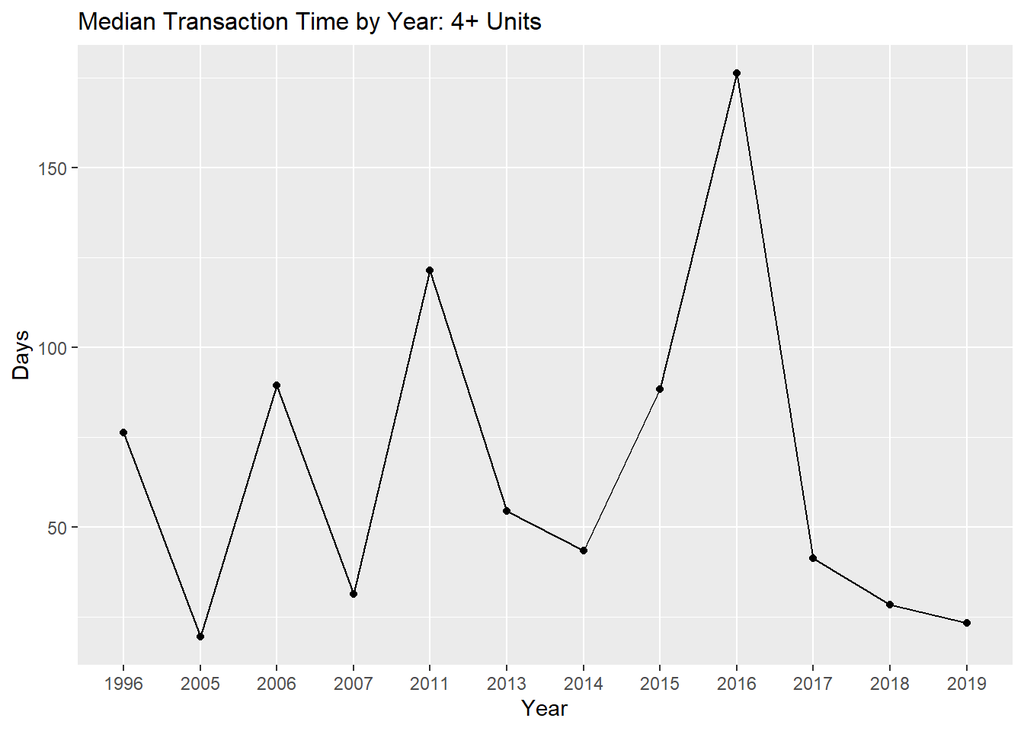

```r
qh_epa_4plus <- qh_epa %>%
  select(APN_new, FA_ContractDate, FA_CloseDate, FA_OffMarketDate, FA_ListDate, FA_PropertyType, NumberOfTotalUnits) %>%
  mutate_at(vars(FA_ContractDate, FA_CloseDate, FA_OffMarketDate, FA_ListDate), as.Date, format="%Y-%m-%d") %>% mutate(FA_PropertyType = case_when(NumberOfTotalUnits >=4 ~ '4+ Units', TRUE ~ 'Not 4+ Units')) %>% filter(FA_PropertyType == "4+ Units")

qh_epa_4plus$max.date <- apply(qh_epa_4plus[,2:4],1,max, na.rm=TRUE)

qh_epa_prop2_4plus <- qh_epa_4plus %>%
  drop_na(max.date) %>%
  distinct(APN_new, max.date, .keep_all=TRUE) %>%
  mutate(transaction_time = difftime(max.date, FA_ListDate, units='days'),
         ListDateYear = format(as.Date(max.date), format="%Y"))

transaction_median_4plus <- qh_epa_prop2_4plus %>%
  group_by(ListDateYear) %>%
  summarise(median = median(transaction_time),
            n = n())

ggplot(data = transaction_median_4plus, aes(x = ListDateYear, y=median, group = 1)) +
  geom_line() +
  geom_point() +
  xlab("Year") +
  ylab("Days") +
  ggtitle("Median Transaction Time by Year: 4+ Units") +
  theme(plot.title = element_text(size = 12))
```

Determining percentages greater than given transaction time bounds (130 days for SF, 265 days for 2-3 units, 355 days for 4+ units):

```r
print(sum(qh_epa_prop2_SF$transaction_time >= 130)/nrow(qh_epa_prop2_SF) * 100)
```

```
## [1] 17.42331
```

```r
print(sum(qh_epa_prop2_2to3$transaction_time >= 265)/nrow(qh_epa_prop2_2to3) * 100)
```

```
## [1] 2.564103
```

```r
print(sum(qh_epa_prop2_4plus$transaction_time >= 355)/nrow(qh_epa_prop2_SF) * 100)
```

```
## [1] 0
```

**Median Sale Prices by Tenure**

```r
tax_epa_apn$SALE_YEAR <- substr(tax_epa_apn$`SALE DATE`, 0, 4)

absentee_epa <- tax_epa_apn %>% filter(`ABSENTEE OWNER STATUS` == "A")
owner_epa <- tax_epa_apn %>% filter(`ABSENTEE OWNER STATUS` == "O")

median_absentee <- data.frame("Sale_Price" = absentee_epa$`SALE PRICE`, "Sale_Year" = absentee_epa$SALE_YEAR) %>% group_by(Sale_Year) %>% summarize(median = median(Sale_Price))
median_owner <- data.frame("Sale_Price" = owner_epa$`SALE PRICE`, "Sale_Year" = owner_epa$SALE_YEAR) %>% group_by(Sale_Year) %>% summarize(median = median(Sale_Price))
```

## Leaflet Setup

**East Palo Alto Map**

```r
epa_map <- block_groups("CA", "San Mateo", cb = T, progress_bar = F) %>%
  filter(TRACTCE %in% c("611800", "611900", "611901", "611902", "612000", "612001", "612002", "612100", "612101", "612102")) %>%
  select(c(TRACTCE,BLKGRPCE,GEOID,geometry)) %>% rename("cbg" = "GEOID")
```

```r
epa_demo_map <- epa_map %>% left_join(demo_epa, by = "cbg") %>% left_join(pop_epa, by = "cbg")

res_pal_2 <- colorNumeric(
  palette = "Blues",
  domain = (1 - epa_demo_map$`White alone`/epa_demo_map$`Population`)
)

leaflet() %>%
  addProviderTiles(providers$CartoDB.Positron) %>%
  addPolygons(
    data = epa_demo_map,
    weight = 3,
    color = res_pal_2(1 - epa_demo_map$`White alone`/epa_demo_map$`Population`),
    label = ~paste0("CBG ", TRACTCE,BLKGRPCE, "; Population: ", `Population`, "; Non-White Percentage: ", round((1 - epa_demo_map$`White alone`/epa_demo_map$`Population`) * 100, 1)),
    highlightOptions = highlightOptions(
      weight = 3,
      opacity = 1)
  ) %>%
  addLegend(
    data = epa_demo_map,
    pal = res_pal_2,
    values = ~as.numeric((1 - epa_demo_map$`White alone`/epa_demo_map$`Population`)),
    title = "Population in EPA, by Fraction of Non-White Population"
  )
```

[interactive chart not shown]

**Housing Unit Inventory Map**

```r
epa_unit_map <- epa_map %>% left_join(unit_table, by = "cbg")

res_pal_2 <- colorNumeric(
  palette = "Reds",
  domain = epa_unit_map$`Renter Occupied Units (25003)`/epa_unit_map$`Total Housing Units (25001)`
)

leaflet() %>%
  addProviderTiles(providers$CartoDB.Positron) %>%
  addPolygons(
    data = epa_unit_map,
    weight = 3,
    color = res_pal_2(epa_unit_map$`Renter Occupied Units (25003)`/epa_unit_map$`Total Housing Units (25001)`),
    label = ~paste0("CBG ", TRACTCE,BLKGRPCE, "; Total Units: ", `Total Housing Units (25001)`, "; Owner-Occupied: ", `Owner Occupied Units (25003)`, "; Renter-Occupied: ", `Renter Occupied Units (25003)`, "; Fraction of Rental Units: ", round(`Renter Occupied Units (25003)`/`Total Housing Units (25001)`, 3)),
    highlightOptions = highlightOptions(
      weight = 3,
      opacity = 1)
  ) %>%
  addLegend(
    data = epa_unit_map,
    pal = res_pal_2,
    values = ~as.numeric(epa_unit_map$`Renter Occupied Units (25003)`/epa_unit_map$`Total Housing Units (25001)`),
    title = "Housing Units in EPA, by Fraction of Rental Units"
  )
```

[interactive chart not shown]

**Unused and Unproductive Code**

Housing Inventory using QH data: This was found to not produce the desired outcome of counting housing units in East Palo Alto.

```r
# unit_inventory <- qh_epa %>% select(FA_PropertyType, NumberOfTotalUnits) %>% group_by(FA_PropertyType) %>% summarize(sum = sum(NumberOfTotalUnits, na.rm = TRUE))
#
# property_inventory <- data.frame(table(qh_epa$FA_PropertyType))
```

Renters, Owners, Total: This was replaced by ACS5 data that could more clearly define tenure.

```r
# Year <- c("2016", "2017", "2018", "2019")
# Renters <- c(sum(opaeligibility$`2016.x`=="Renter", na.rm = TRUE), sum(opaeligibility$`2017.x`=="Renter", na.rm = TRUE), sum(opaeligibility$`2018.x`=="Renter", na.rm = TRUE), sum(opaeligibility$`2019.x`=="Renter", na.rm = TRUE))
# Owners <- c(sum(opaeligibility$`2016.x`=="Owner", na.rm = TRUE), sum(opaeligibility$`2017.x`=="Owner", na.rm = TRUE), sum(opaeligibility$`2018.x`=="Owner", na.rm = TRUE), sum(opaeligibility$`2019.x`=="Owner", na.rm = TRUE))
# Total <- Renters + Owners
#
# data.frame(Year, Renters, Owners, Total)

# sum(opaeligibility$`2016.x`=="Renter", na.rm = TRUE)
# sum(opaeligibility$`2016.x`=="Owner", na.rm = TRUE)
# sum(opaeligibility$`2017.x`=="Renter", na.rm = TRUE)
# sum(opaeligibility$`2017.x`=="Owner", na.rm = TRUE)
# sum(opaeligibility$`2018.x`=="Renter", na.rm = TRUE)
# sum(opaeligibility$`2018.x`=="Owner", na.rm = TRUE)
# sum(opaeligibility$`2019.x`=="Renter", na.rm = TRUE)
# sum(opaeligibility$`2019.x`=="Owner", na.rm = TRUE)
```